# 950 Final Project

Haoyu Zhang

2018-03-29

# 1 About the dataset

- The dataset consist of two subsets. One subset (dataset A) includes application data for every customer that has been given a loan in a 6 month period. The other (dataset B) contains every loan that has been given in this time and whether it has been a good loan or a bad loan.
- The goal of this project is to identify which new applicants should be given a loan in the future or not, using the two datasets (A&B).
- Other potential outcome from this project is to discuss any problems or limitations with the data, shortcomings of differenct analysis regime.

# 2 Introduction

- This problem could be treated as an unsupervised (binary) clustering problem which a machine learning technique will be deployed or a supervised binary classification problem which will be fitted in to a logistic regression model.
- Structure of this presentation: – Datasets Overview – Preprocessing – Diagnostic – Variable selection – Modeling – Optimization – Discussion and comparison

# 3 Preparations—load libraries and functions

# 4 Dataset overview

## 4.1 dataset A

```r
dataset_1 = read.xls('950_Data.xlsx',sheet = 2,head=TRUE) %>% data.table()
glimpse(dataset_1)
```

```
## Observations: 647
## Variables: 31
## $ customer_id                 <fctr> 9ece67d6c5, 5c2c402094, e6254cad3...
## $ amount_requested            <int> 500, 500, 400, 500, 300, 400, 300,...
## $ birth_date                  <fctr> 1991-08-21, 1990-07-24, 1980-09-1...
## $ status                      <fctr> Approved, Approved, Approved, App...
## $ residence_rent_or_own       <lgl> TRUE, TRUE, TRUE, FALSE, TRUE, FAL...
## $ monthly_rent_amount         <int> 0, 0, 620, 785, 700, 1600, 865, 10...
## $ bank_account_direct_deposit <lgl> TRUE, FALSE, TRUE, FALSE, TRUE, TR...
## $ application_when            <fctr> 2010-10-16 14:06:05.00, 2010-10-1...
## $ loan_duration               <int> 3, 6, 6, 4, 4, 4, 4, 2, 4, 6, 4, 6...
## $ payment_ach                 <lgl> TRUE, TRUE, TRUE, TRUE, TRUE, TRUE...
## $ num_payments                <int> 6, 13, 13, 8, 8, 4, 4, 4, 4, 13, 8...
## $ payment_amount              <dbl> 138.48, 77.39, 61.91, 108.48, 65.0...
## $ amount_approved             <int> 500, 500, 400, 500, 300, 400, 300,...
```

[output cut: 18 more lines]

**numerical covariates**:

monthly_rent_amount, **amount_requested, amount_approved**, num_payments, **payment_amount, payment_amount_approved**, *monthly_income_amount*, **loan_duration, duration_approved**, raw_l2c_score, *raw_FICO_telecom, raw_FICO_retail, raw_FICO_bank_card, raw_FICO_money*

**logical**:

*residence_rent_or_own*, *bank_account_direct_deposit*, payment_ach

**ordinal**:

email_duration, *residence_duration*, bank_account_duration, payment_frequency

**categorical**:

status, **address_zip**, **bank_routing_number**, email, home_phone_type, other_phone_type, how_use_money

**time**:

*birth_date*, application_when

## 4.2 dataset B

```r
dataset_2 = read.xls('950_Data.xlsx',sheet = 3,head=TRUE) %>% data.table()
glimpse(dataset_2)
```

```
## Observations: 1,285
## Variables: 2
## $ idLoan  <fctr> 0DBA6B011D-01, 96ACBBA7ED-01, 289421D82A-01, 9ECE67D6...
## $ flgGood <fctr> Bad, Bad, Bad, Good, Bad, Good, Good, Bad, Good, Good...
```

One may note that dataset B has more observations than dataset A. Also, idLoan in dataset B is connected to customer_id in dataset A.

# 5 Preprocessing Dataset

## 5.1 aggregation of the set A and set B

```r
cat('parse dataset B')
```

```
## parse dataset B
```

```r
dataset_2[,':=' (flgGood = (flgGood == 'Good')*as.integer(1),
                 customer_id =  str_sub(tolower(idLoan),1,-4),
                 idx = str_sub(tolower(idLoan),-2,-1))]
head(dataset_2)
```

```
##           idLoan flgGood customer_id idx
## 1: 0DBA6B011D-01       0  0dba6b011d  01
## 2: 96ACBBA7ED-01       0  96acbba7ed  01
## 3: 289421D82A-01       0  289421d82a  01
## 4: 9ECE67D6C5-01       1  9ece67d6c5  01
## 5: 5C2C402094-01       0  5c2c402094  01
## 6: E6254CAD30-01       1  e6254cad30  01
```

```r
cat('The percentage of customer in dataset A who are masked in dataset B:',mean(dataset_1$customer_id %in%dataset_2$customer_id)*100)
```

```
## The percentage of customer in dataset A who are masked in dataset B: 98.91808
```

```r
cat('delete duplicated')
```

```
## delete duplicated
```

```r
idx <- duplicated(dataset_2, by=c('customer_id','flgGood'))
dataset_2 <- dataset_2[!idx,]

cat('delete mixing flgGood')
```

```
## delete mixing flgGood
```

```r
idx <- duplicated(dataset_2, by=c('customer_id'))
ids <- dataset_2[idx,]$customer_id
dataset_2 <- dataset_2[!customer_id %in% ids,]

cat('full dataset')
```

```
## full dataset
```

```r
dt <- inner_join(dataset_1,dataset_2[,c('customer_id', 'flgGood')],
                      by="customer_id") %>% data.table()
```

In the full dataset, a good loan has covariate flgGood equal 1 otherwise 0 for a bad loan.

## 5.2 preprocessing

Even the full dataset is very messy, more data cleaning work is required before any modeling.

```r
glimpse(dt)
```

```
## Observations: 637
## Variables: 32
## $ customer_id                 <chr> "9ece67d6c5", "5c2c402094", "e6254...
## $ amount_requested            <int> 500, 500, 400, 500, 300, 400, 300,...
## $ birth_date                  <fctr> 1991-08-21, 1990-07-24, 1980-09-1...
## $ status                      <fctr> Approved, Approved, Approved, App...
## $ residence_rent_or_own       <lgl> TRUE, TRUE, TRUE, FALSE, TRUE, FAL...
## $ monthly_rent_amount         <int> 0, 0, 620, 785, 700, 1600, 865, 10...
## $ bank_account_direct_deposit <lgl> TRUE, FALSE, TRUE, FALSE, TRUE, TR...
## $ application_when            <fctr> 2010-10-16 14:06:05.00, 2010-10-1...
## $ loan_duration               <int> 3, 6, 6, 4, 4, 4, 4, 2, 4, 6, 4, 6...
## $ payment_ach                 <lgl> TRUE, TRUE, TRUE, TRUE, TRUE, TRUE...
## $ num_payments                <int> 6, 13, 13, 8, 8, 4, 4, 4, 4, 13, 8...
## $ payment_amount              <dbl> 138.48, 77.39, 61.91, 108.48, 65.0...
## $ amount_approved             <int> 500, 500, 400, 500, 300, 400, 300,...
```

[output cut: 19 more lines]

```r
cat('covariates with only one value : status, payment_ach')
```

```
## covariates with only one value : status, payment_ach
```

```r
table(dt$status)
```

```
##
## Approved
##      637
```

```r
table(dt$payment_ach)
```

```
##
## FALSE  TRUE
##     1   636
```

```r
dt[,':=' (status = NULL, payment_ach = NULL)]
```

Covariates with only one value will be excluded from the full dataset.

Logical covariates are converted into 0 and 1, denoting false and true, respectively. Time covariates either are treated as integer (birth day) or categorical variable (application time).

```r
cat('logical: residence_rent_or_own, bank_account_direct_deposit')
```

```
## logical: residence_rent_or_own, bank_account_direct_deposit
```

```r
dt[,':=' (residence_rent_or_own = residence_rent_or_own*as.integer(1),
          bank_account_direct_deposit = bank_account_direct_deposit*as.integer(1))]

cat('categorical: email')
```

```
## categorical: email
```

```r
dt <- separate(dt, email, c('names','domain'),sep='@') #gsub(".*@|\\..*", "\\1", emails)
dt[, ':=' (names=NULL,domain = as.factor(domain))] # names doesn't mean anything

cat('time: birth_date -> age, application_when')
```

```
## time: birth_date -> age, application_when
```

```r
dt[, ':=' (age = calc_age(as.Date(birth_date)),
                application_when = as.Date(application_when))]
dt[, ':=' (year = year(ymd(application_when)),month = month(ymd(application_when)), day = day(ymd(application_when)),
                dow = weekdays(dt$application_when))]
dt[, ':=' (application_when = NULL,
                birth_date = NULL,
                dow = as.integer(as.factor(dow)))]

cat('ordinal: email_duration, residence_duration, bank_account_duration, payment_frequency')
```

```
## ordinal: email_duration, residence_duration, bank_account_duration, payment_frequency
```

```r
dt[, ':=' (bank_account_duration = as.factor(ordered(dt$bank_account_duration, exclude = NA,
                                                     levels = c("6 months or less","7-12 months","1-2 years","3+ years"),
                                                     labels = c(1,2,3,4))),
           residence_duration = as.factor(ordered(dt$residence_duration, exclude = NA,
                                                  levels = c("6 months or less","7-12 months","1-2 years","3+ years"),
                                                  labels = c(1,2,3,4))),
           email_duration = as.factor(ordered(dt$email_duration, exclude = NA,
                                              levels = c("3 months or less","4-12 months","1 year or more"),
                                              labels = c(1,2,3))),
           payment_frequency = as.factor(ordered(dt$payment_frequency, exclude = NA,
                                                 levels = c("Weekly","Bi-weekly","Semi-monthly","Monthly"),
                                                 labels = c(1,2,3,4))))]
```

# 6 Data diagnostics

For real data, one can expect various issues in the dataset listing from missing data, outliers, multicollinearity, and severe violation from normality and so on. We first start with variable visualizations.

## 6.1 amount required VS amount approved

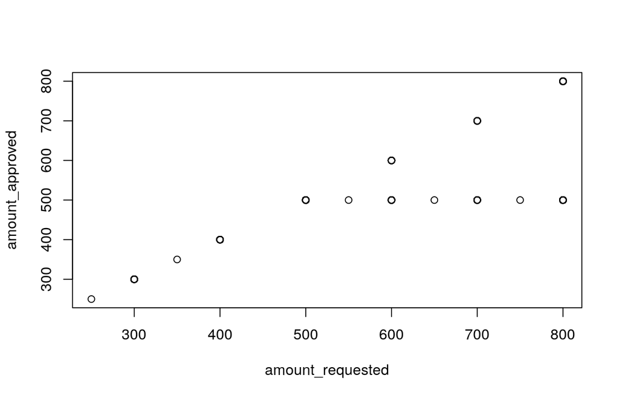

```r
plot(dt$amount_requested,dt$amount_approved,xlab ='amount_requested',ylab='amount_approved')
```

It shows strong collinearity between amount_requested and amount_approved.  
Any requested amounts below 500 are granted. Any amounts >= 500 are either granted or reduced to 500. Some decision mechanism is already involved, might be leaky.

```r
idx<-which(dt$amount_requested==dt$amount_approved)
idx1<-which(dt$amount_approved<=500)%in%idx
idx2<-which(dt$amount_approved>500)%in%idx

cat('target mean for unapproved loan | approved loan (<=500) | approved loan (>500)')
```

```
## target mean for unapproved loan | approved loan (<=500) | approved loan (>500)
```

```r
mean(dt$flgGood[-idx]);mean(dt$flgGood[idx1]);mean(dt$flgGood[idx2])
```

```
## [1] 0.3858696
```

```
## [1] 0.4513064
```

```
## [1] 0.4489796
```

## 6.2 loan_duration VS duration approved

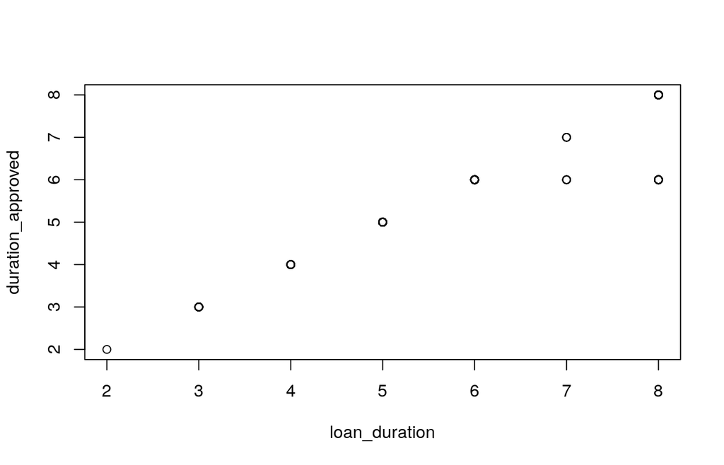

```r
plot(dt$loan_duration, dt$duration_approved, xlab ='loan_duration',ylab='duration_approved')
```

Similarly, collinearity between loan_duration and duration_approved, any loan_duration shorter than 6 are approved, while those greater than 6 are either approved or reduced to 6, again, credit decision might be involved.

```r
length(which((dt$loan_duration-dt$duration_approved)==0))
```

```
## [1] 513
```

```r
idx<-which(dt$loan_duration==dt$duration_approved)
idx1<-which(dt$duration_approved<=6)%in%idx
idx2<-which(dt$duration_approved>6)%in%idx

cat('flgGood mean for unapproved loan duration | approved loan <=6 | approved loan >6')
```

```
## flgGood mean for unapproved loan duration | approved loan <=6 | approved loan >6
```

```r
mean(dt$flgGood[-idx]);mean(dt$flgGood[idx1]);mean(dt$flgGood[idx2])
```

```
## [1] 0.4112903
```

```
## [1] 0.449505
```

```
## [1] 0.4489796
```

## 6.3 payment_amount VS payment_amount_approved

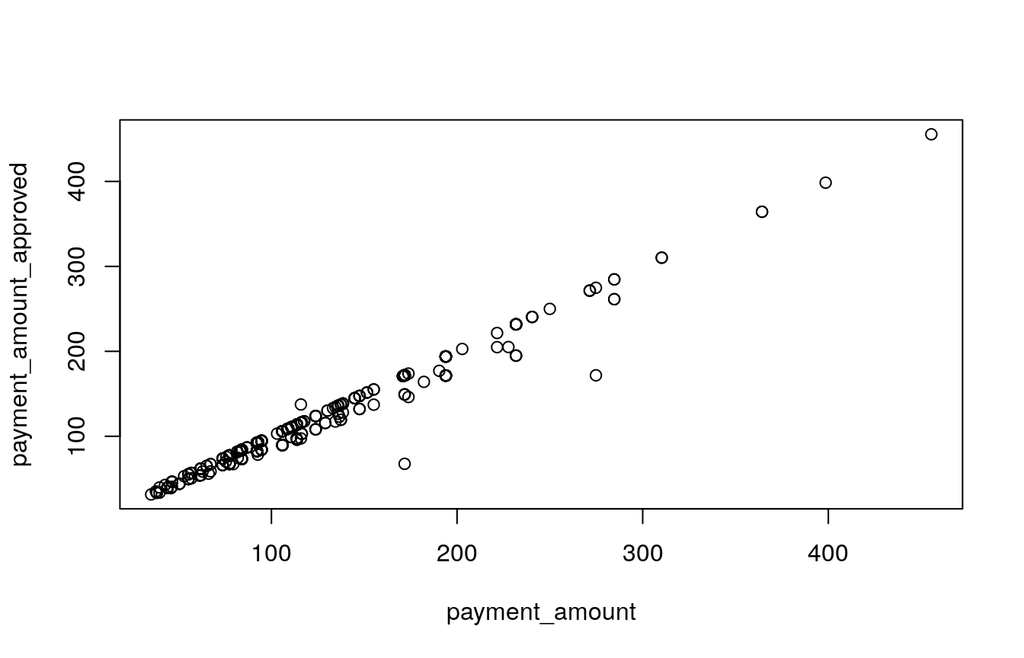

```r
plot(dt$payment_amount,dt$payment_amount_approved,xlab ='payment_amount',ylab='payment_amount_approved')
```

Yet, another strong collinearity

## 6.4 more collinearity among covariates

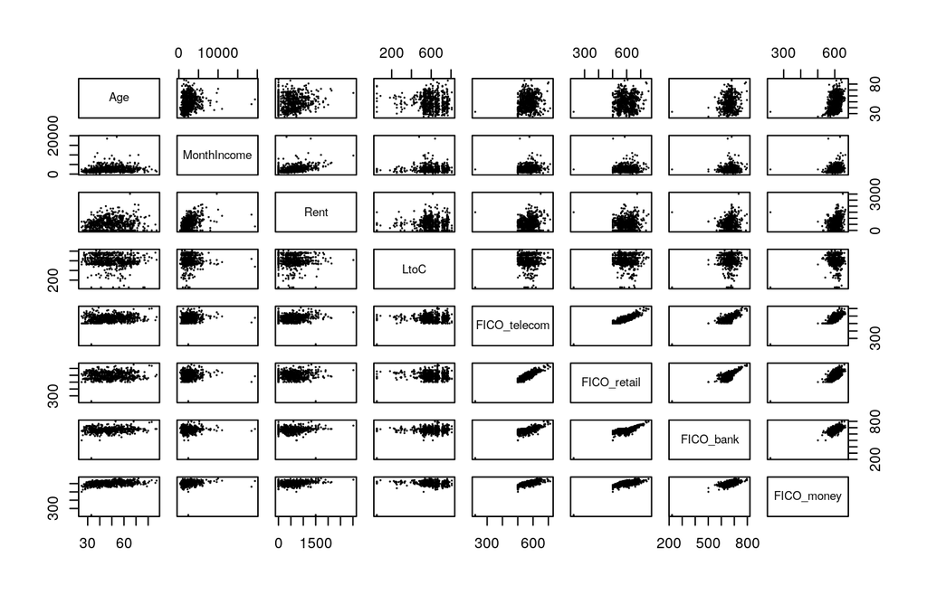

```r
collinear.df<-data.frame(Age=dt$age,
                         MonthIncome=dt$monthly_income_amount,
                         Rent=dt$monthly_rent_amount,
                         LtoC=dt$raw_l2c_score,
                         FICO_telecom=dt$raw_FICO_telecom,
                         FICO_retail=dt$raw_FICO_retail,
                         FICO_bank=dt$raw_FICO_bank_card,
                         FICO_money=dt$raw_FICO_money)
pairs(collinear.df,cex=0.01)
```

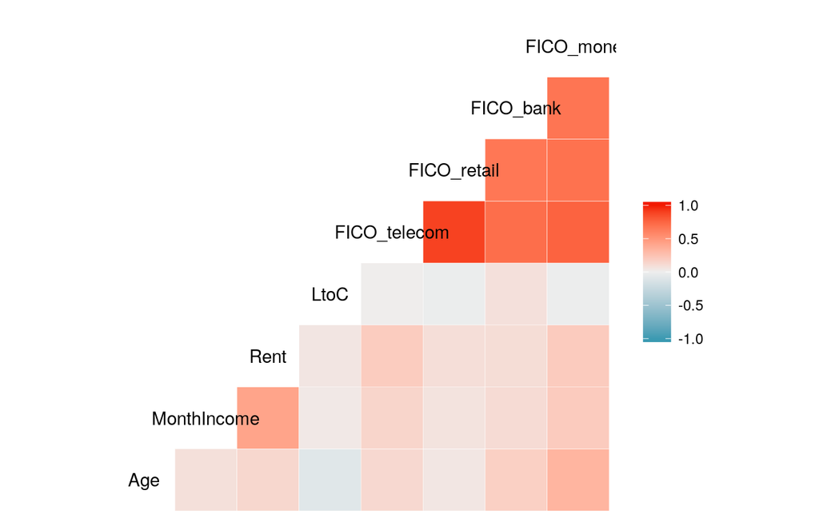

```r
ggcorr(collinear.df,label_size = 0.1)
```

FICO scores more or less linearly correlate to each other.

## 6.5 FICO

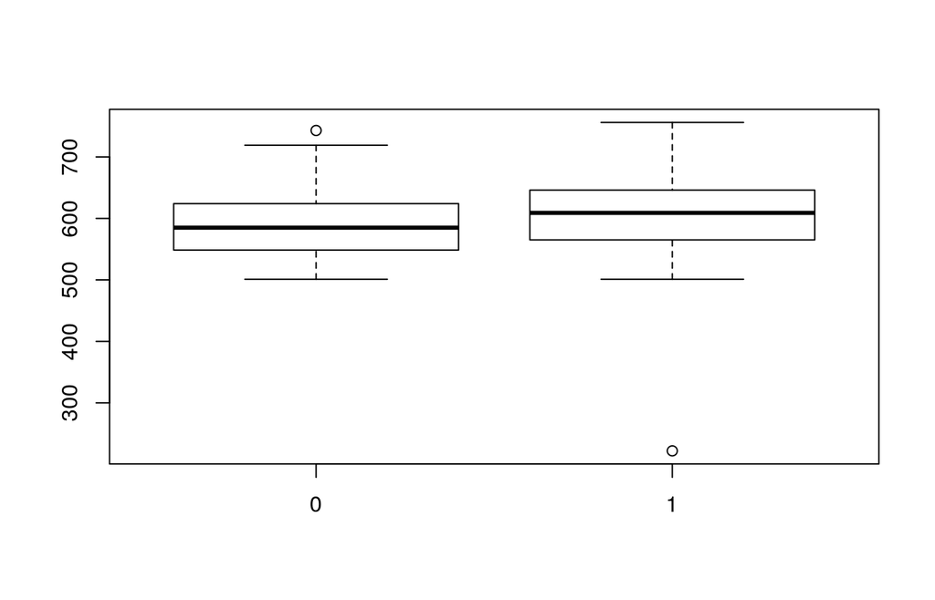

```r
boxplot(dt$raw_FICO_retail~dt$flgGood)
```

```r
#print(summary(dt$raw_FICO_retail[dt$flgGood==1]))
#print(summary(dt$raw_FICO_retail[dt$flgGood==0]))
t.test(dt$raw_FICO_retail[dt$flgGood==1], dt$raw_FICO_retail[dt$flgGood==0])
```

```
##
##  Welch Two Sample t-test
##
## data:  dt$raw_FICO_retail[dt$flgGood == 1] and dt$raw_FICO_retail[dt$flgGood == 0]
## t = 4.6214, df = 562.1, p-value = 4.732e-06
## alternative hypothesis: true difference in means is not equal to 0
## 95 percent confidence interval:
##  11.06191 27.41594
## sample estimates:
## mean of x mean of y
##  607.2902  588.0513
```

The raw_FICO_retail shows significant difference between good- or bad-loan groups, and some outliers, better removed for linear models.

## 6.6 monthly_income_amount

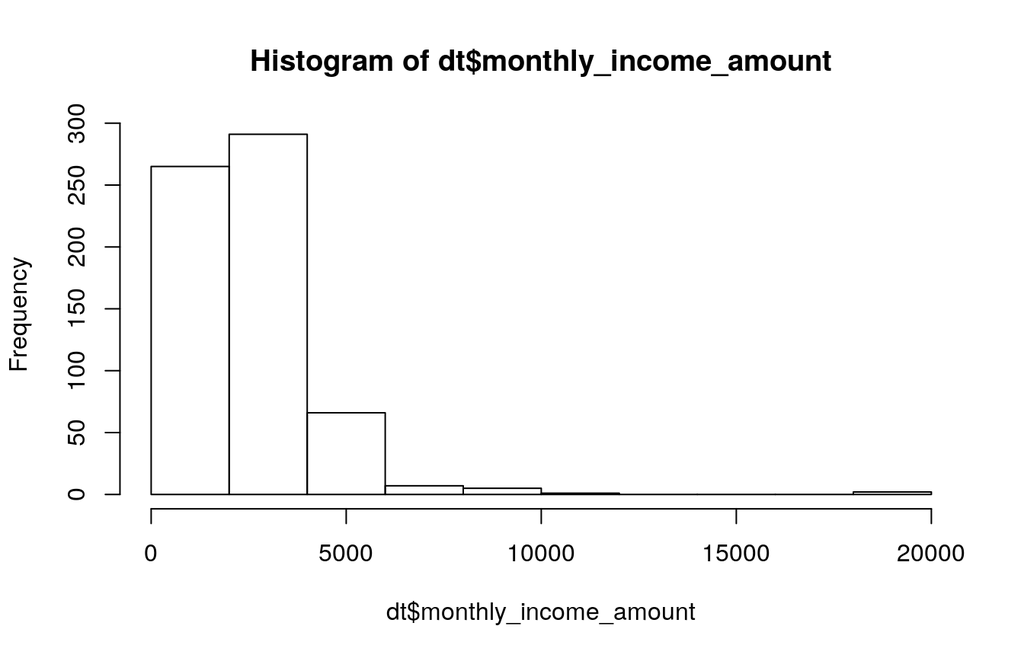

```r
hist(dt$monthly_income_amount)
```

Most of the monthly income amounts located <5000.

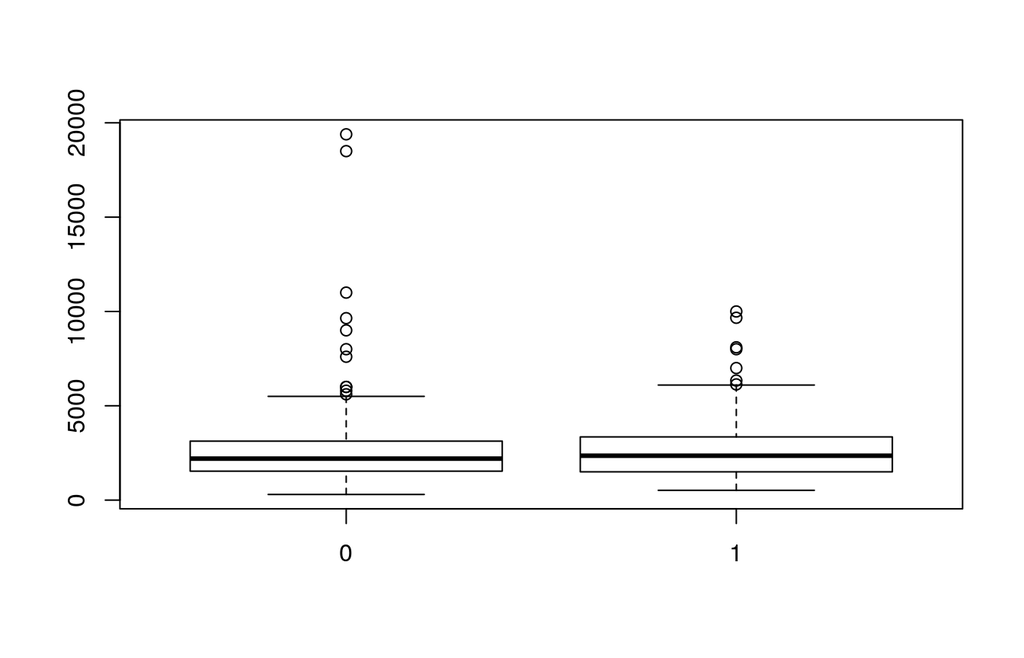

```r
boxplot(dt$monthly_income_amount~dt$flgGood)
```

```r
t.test(dt$monthly_income_amount[dt$flgGood==1], dt$monthly_income_amount[dt$flgGood==0])
```

```
##
##  Welch Two Sample t-test
##
## data:  dt$monthly_income_amount[dt$flgGood == 1] and dt$monthly_income_amount[dt$flgGood == 0]
## t = 0.36045, df = 634.6, p-value = 0.7186
## alternative hypothesis: true difference in means is not equal to 0
## 95 percent confidence interval:
##  -215.2940  312.1002
## sample estimates:
## mean of x mean of y
##  2643.500  2595.097
```

Intuitively, monthly_income_amount is expected to be a good indicator for a new applicant’s trustability. However, t-test tells the opposite. Moreover, many outliers for bad loans show suspecious high monthly income amount, might be fake/fraud data.

## 6.7 age

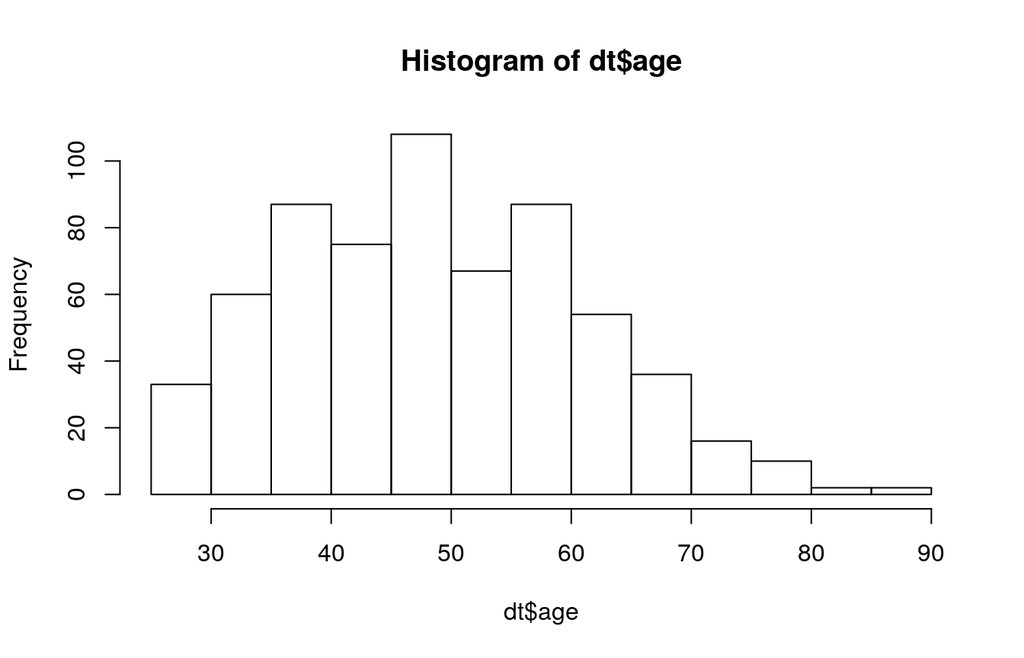

```r
hist(dt$age)
```

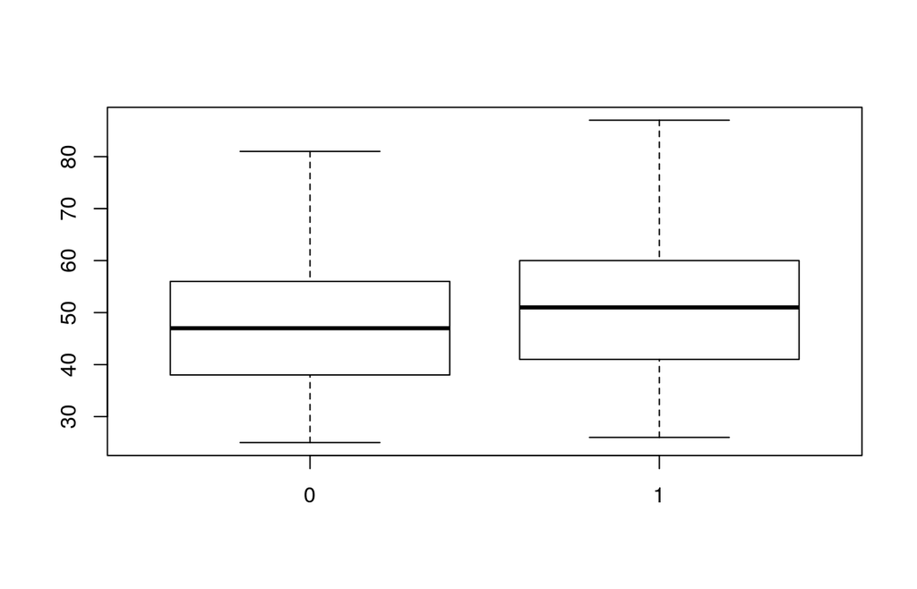

```r
boxplot(dt$age~dt$flgGood)
```

```r
# summary(dt$age)
t.test(dt$age[dt$flgGood==1], dt$age[dt$flgGood==0])
```

```
##
##  Welch Two Sample t-test
##
## data:  dt$age[dt$flgGood == 1] and dt$age[dt$flgGood == 0]
## t = 3.9221, df = 592.5, p-value = 9.806e-05
## alternative hypothesis: true difference in means is not equal to 0
## 95 percent confidence interval:
##  1.907141 5.732849
## sample estimates:
## mean of x mean of y
##  51.25874  47.43875
```

The age shows significant difference between good- or bad-loan groups, as expected, can be a good predictor.

## 6.8 how_use_money

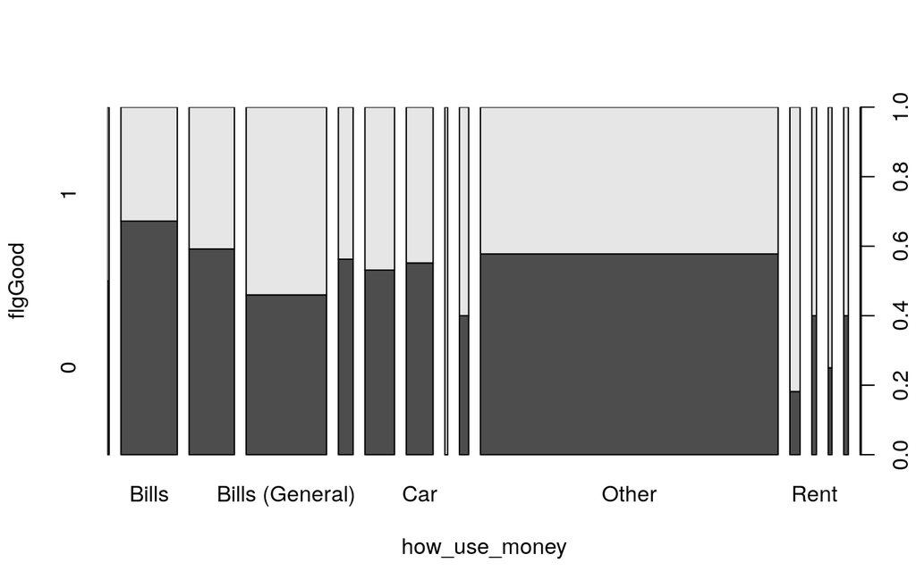

```r
plot(dt$how_use_money,as.factor(dt$flgGood), ylab='flgGood', xlab='how_use_money')
```

Clearly, how the applicant use the money affect how good the loan will be.

## 6.9 payment_frequency

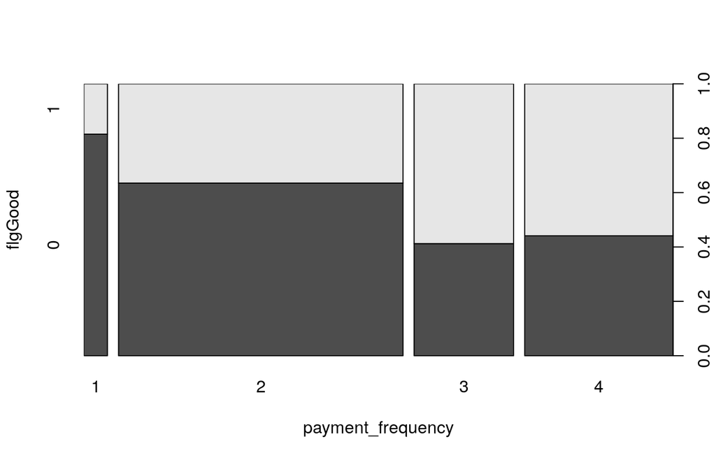

```r
plot(dt$payment_frequency,as.factor(dt$flgGood), ylab='flgGood', xlab='payment_frequency')
```